# R for Data Science

### 3.3.1 Exercises

**1. What’s wrong with this code? Why are the point not blue?**

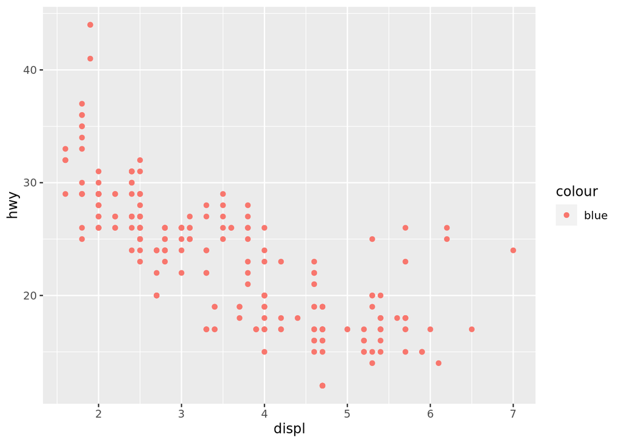

```r
ggplot(data = mpg) +
  geom_point(mapping = aes(x = displ, y = hwy, color = "blue"))
```

The `color` aesthetic inside the `aes` function created a category called `blue` that all the points belong to. Anything within the `aes` function is attempting to be mapped to a variable in the data, rather than a property of the general graph. To get points plotted in blue:

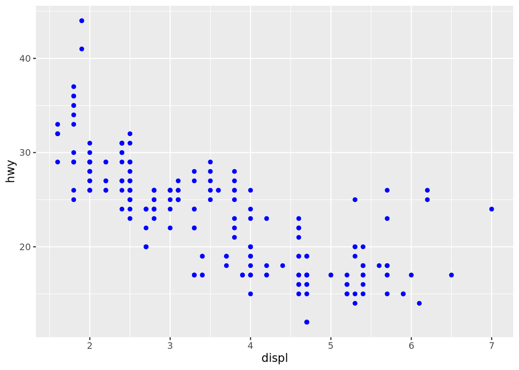

```r
ggplot(data = mpg) +
  geom_point(mapping = aes(x = displ, y = hwy), color = "blue")
```

**2. Which variables in `mpg` are categorical? Which variables are continuous? How can you see this informaiton when you run `mpg`?**

```r
mpg
```

```
## # A tibble: 234 x 11
##    manufacturer model    displ  year   cyl trans   drv     cty   hwy fl    class
##    <chr>        <chr>    <dbl> <int> <int> <chr>   <chr> <int> <int> <chr> <chr>
##  1 audi         a4         1.8  1999     4 auto(l… f        18    29 p     comp…
##  2 audi         a4         1.8  1999     4 manual… f        21    29 p     comp…
##  3 audi         a4         2    2008     4 manual… f        20    31 p     comp…
##  4 audi         a4         2    2008     4 auto(a… f        21    30 p     comp…
##  5 audi         a4         2.8  1999     6 auto(l… f        16    26 p     comp…
##  6 audi         a4         2.8  1999     6 manual… f        18    26 p     comp…
##  7 audi         a4         3.1  2008     6 auto(a… f        18    27 p     comp…
##  8 audi         a4 quat…   1.8  1999     4 manual… 4        18    26 p     comp…
##  9 audi         a4 quat…   1.8  1999     4 auto(l… 4        16    25 p     comp…
## 10 audi         a4 quat…   2    2008     4 manual… 4        20    28 p     comp…
## # … with 224 more rows
```

Here, each collumn is has its type listed in brackets beneath the column name. Any variable that is a character string `<chr>` or an integer `<int>` can be considered categorical. Variables of type `<dbl>` are of type double and continuous.

**3. Map a continuous variable to `color`, `size`, and `shape`. How do these aesthetics behave differently for categorical vs continuous variables.**

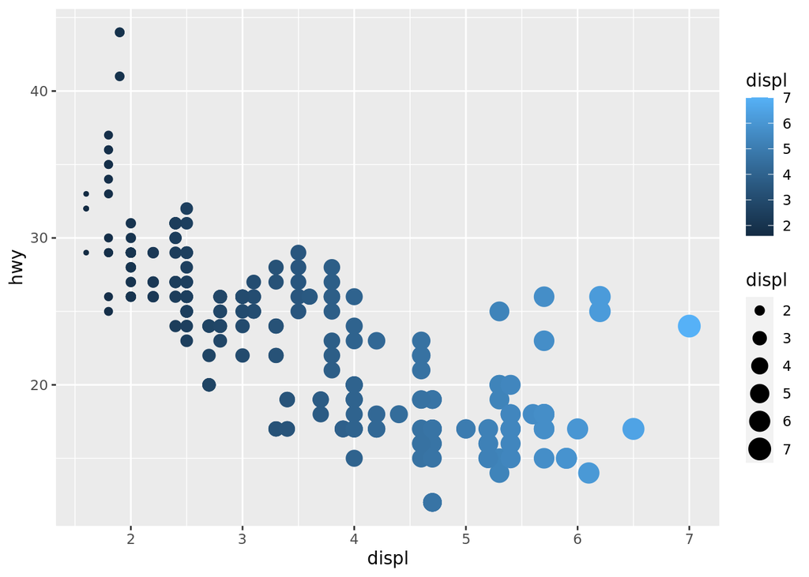

```r
ggplot(data = mpg) +
  geom_point( mapping = aes(x = displ, y = hwy, color = displ, size = displ))
```

For `color` and `size`, the data is mapped to an integer range and a gradient of colors and sizes created. An error occurs when trying to map `shape` to a continuous variaable.

**4. What happens if you map the same variable to multiple aesthetics?**

This was done in Exercise 3, above. `ggplot` is perfectly happy to do this, but it doesn’t add much to the plot. It does emphasize the gradient of the variable.

**5. What does the `stroke` aesthetic do? What shapes does it work with?**

For filled shapes 21-24, stroke is the width of the plotted glyph’s outline.

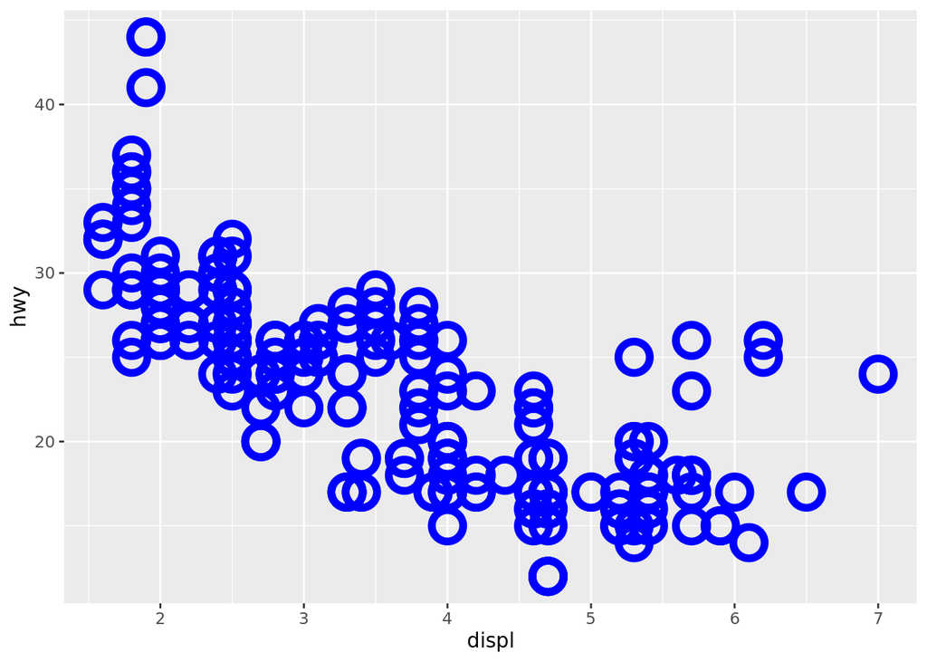

```r
ggplot(data = mpg) +
  geom_point( mapping = aes(x = displ, y = hwy),
              color = 'blue', shape = 21, size = 6, stroke = 3)
```

**6. What happens if you map an aesthetic to something other than a variable name, like `aes(colour = displ < 5)`?**

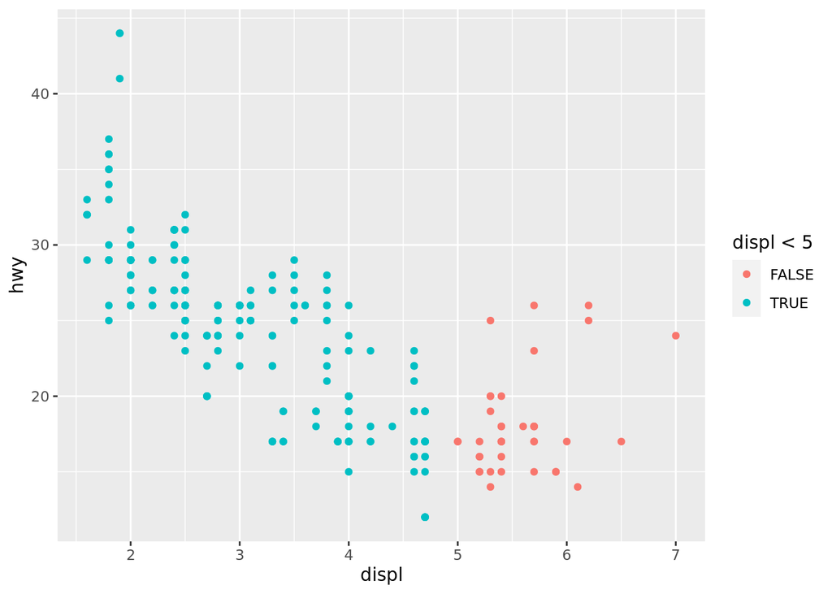

```r
ggplot(data = mpg) +
  geom_point( mapping = aes(x = displ, y = hwy, color = displ < 5))
```

In this case, two groups were created - vehicles with displ < and those with displ >= 5, and each is colored differently.

### 3.5.1 Exercises

**1. What happens if you facet on a continuous variable?**

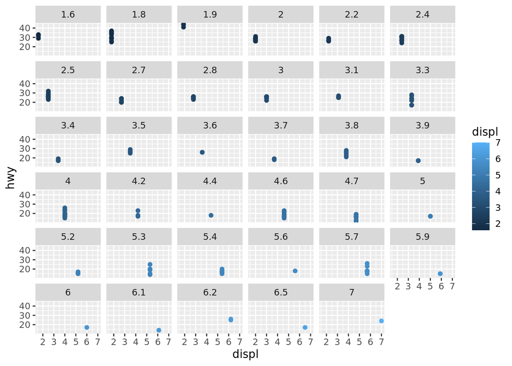

```r
ggplot(data = mpg) +
  geom_point( mapping = aes(x = displ, y = hwy, color = displ)) +
  facet_wrap( ~ displ)
```

One facet for each unique value of the continuous variable was created.

**2. What do the empty cells in plot with `facet_grid(drv~cyl)` mean? How do they relate to this plot?**

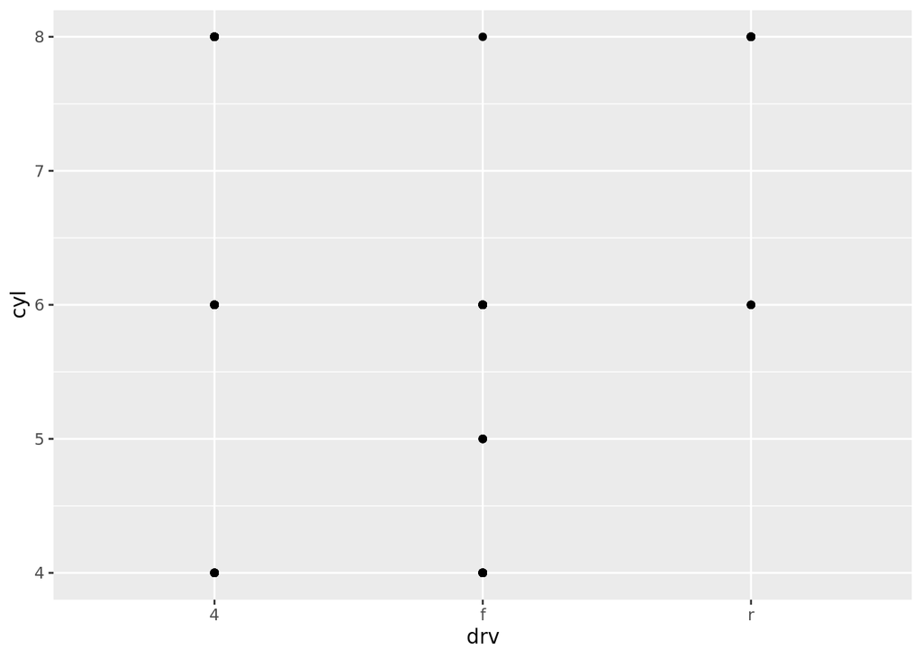

```r
ggplot(data = mpg) +
  geom_point(mapping = aes(x = drv, y = cyl))
```

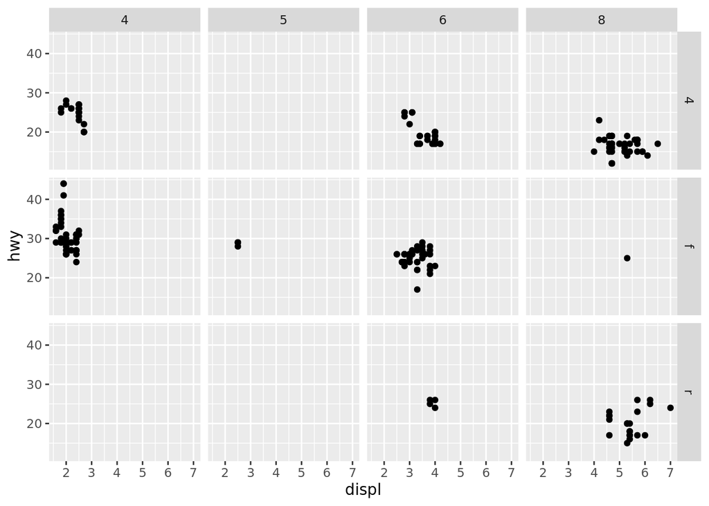

```r
ggplot(data = mpg) +
  geom_point(mapping = aes(x = displ, y = hwy)) +
  facet_grid(drv ~ cyl)
```

There are some combinations of `drv` and `cyl` that do not occur in the original data. For example, rear wheel drive (r) and 4 or 5 cylinders show no point in the categorical scatter plot an also have no plotting on those facets.

**3. What plots does the following ocde make? What does `.` do?**

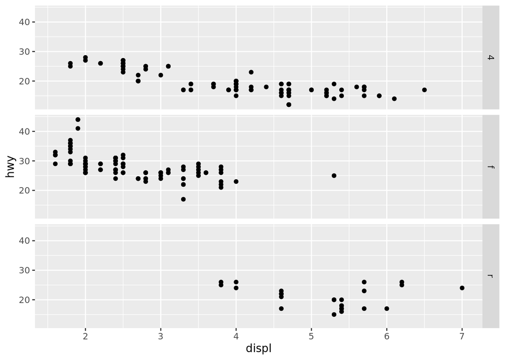

```r
ggplot(data = mpg) +
  geom_point(mapping = aes(x = displ, y = hwy)) +
  facet_grid(drv ~ .)
```

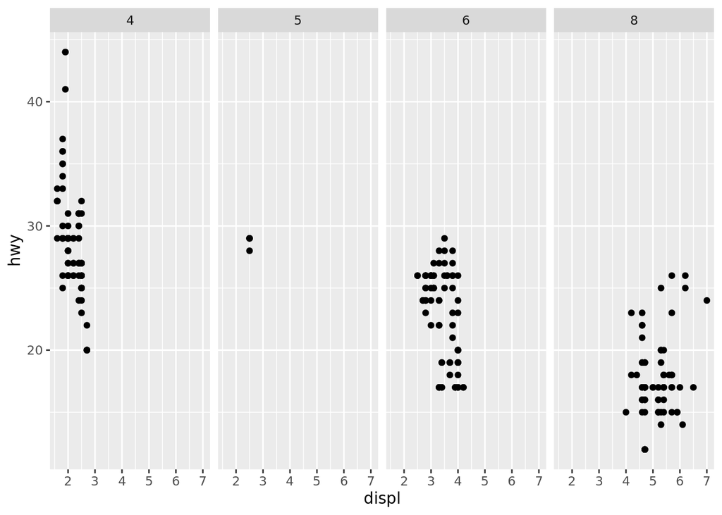

```r
ggplot(data = mpg) +
  geom_point(mapping = aes(x = displ, y = hwy)) +
  facet_grid(. ~ cyl)
```

**4. Take the first faceted plot in this section:**

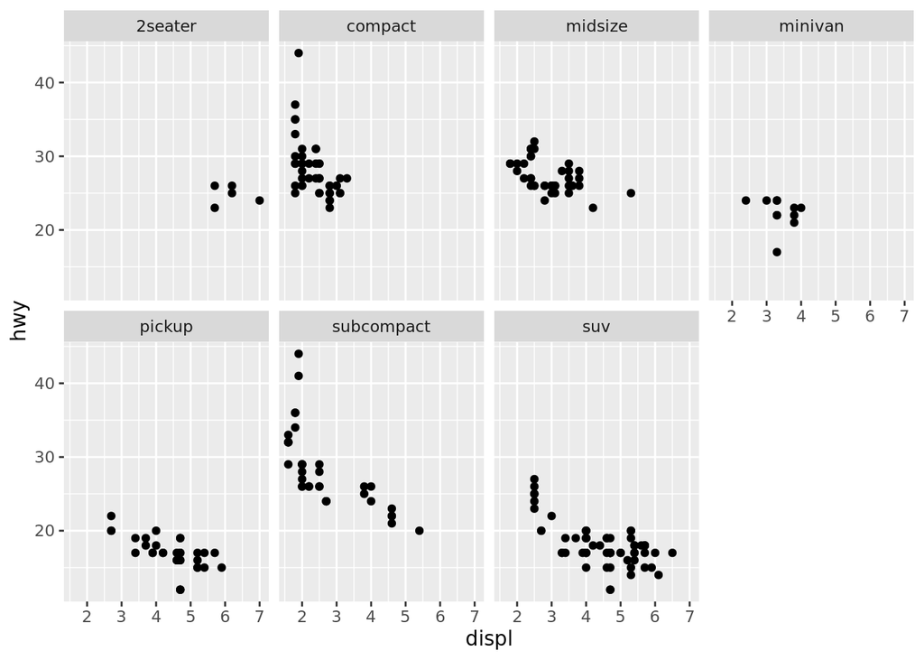

```r
ggplot(data = mpg) +
  geom_point(mapping = aes(x = displ, y = hwy)) +
  facet_wrap(~ class, nrow = 2)
```

What are the advantages to using faceting instead of the colour aesthetic? What are the disadvantages? How might the balance change if you had a larger dataset?

The color aesthetic graph looks like this:

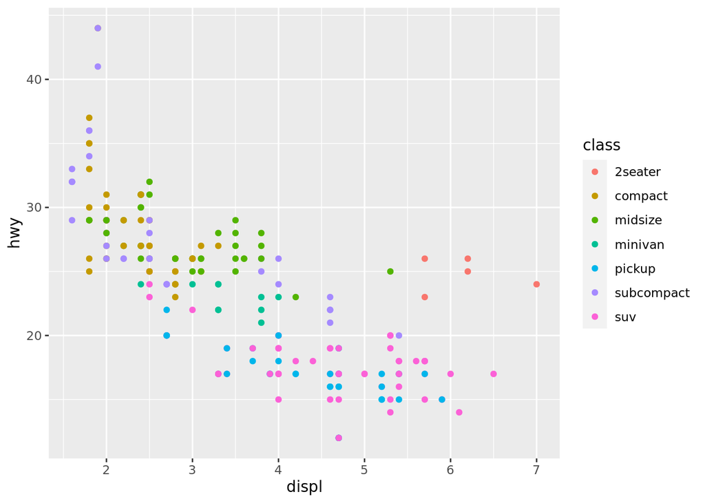

```r
ggplot(data = mpg) +
  geom_point(mapping = aes(x = displ, y = hwy, color = class))
```

The advantages to faceting is that the unique plots are created by category which might be difficult to see on the bottom plot if the dataset was particularly large and disbursed. For a smaller dataset where the data categories for facet or color are well separated, the resulting facet graph ends up with large sections having no points in some facets. This makes is more difficult to compare across facets in a wrapped version like this. Aligning them as all vertical or horizontal would help, but only one axis is comparable at a time in that case.

**5. Read `?facet_wrap`. what does `nrow` do? What does `ncol` do? What other options control the layout of the individual panels? Why doesn’t `facet_grid()` have `nrow` and `ncol` arguments.**

`nrow` and `ncol` contol the number of rows and columns, respectively, for the wrapped facet graph. `as.table` when set to TRUE (the default) lays out like a table with highest values in bottom-right. If FALSE, facets are laid out like a plot with high values at top-right.

`facet_grid()` determines the number of rows and columns from the values that are used in the formula, so `nrow` and `ncol` are defined by the data.

**6. When using `facet_grid()` you should usually put the variable with more unique levels in the columns. Why?**

More unique variables will lead to more columns or rows, and presumably it would be better to have more columns than rows. I would think a balance must be struck between the amount of available plotting area and the number of unique values.

###3.6.1 Exercises

**1. What geom would you use to draw a line chart? A boxplot? A histogram? An area chart?**

`geom_line()` `geom_boxplot()` `geom_histogram()` `geom_area()`

**2. Rn this code in your head and predict what the output will look like. Then run the code in R and check your predictions.**

I would expect a scatterplot with `displ` on the x-axis and `hwy` on the y-axis. Points are colored by `drv`, and a smooth-fit curve is plotted. The `se` parameter determines whether a confidence band is plotted around the smooth-fit curve - here it is not.

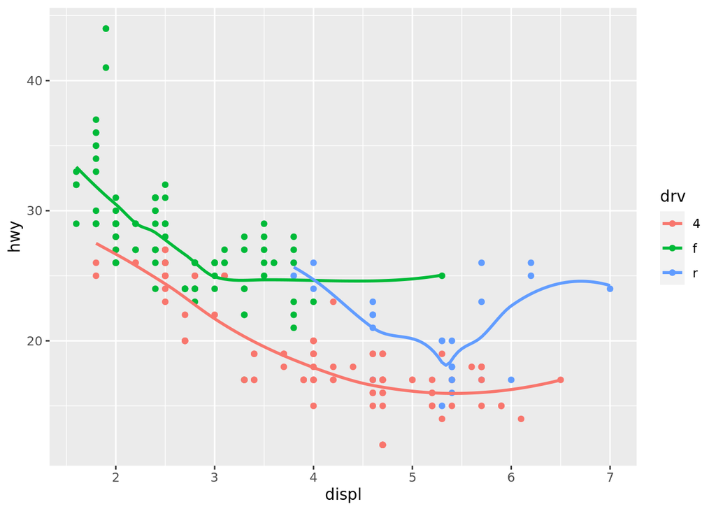

```r
ggplot(data = mpg, mapping = aes(x = displ, y = hwy, color = drv)) +
  geom_point() +
  geom_smooth(se = FALSE)
```

What I missed was that `color = drv` was part of the the aesthetic function, so one line per value of `drv` was created.

**3.What does `show.legend = FALSE` do? What happends if you remove it? What do you thiink I used earlier in the chapter?**

I’m not sure what plot this refers to as `show.legend` doesn’t occur in this chapter. Regardless, it determines whether a categorical legend for an aesthetic is present or not.

**4. What does the `se` argument to `geom_smooth()` do?**

Determines whether a confidence band is plotted around the smooth-fit curve or not.

**5. Will these two graphs look different? Why/why not?**

I predict they will look the same as the mappings between the two is the same. Including it in the `ggplot` call creates it as a global default mapping for all subsequent geom functions.

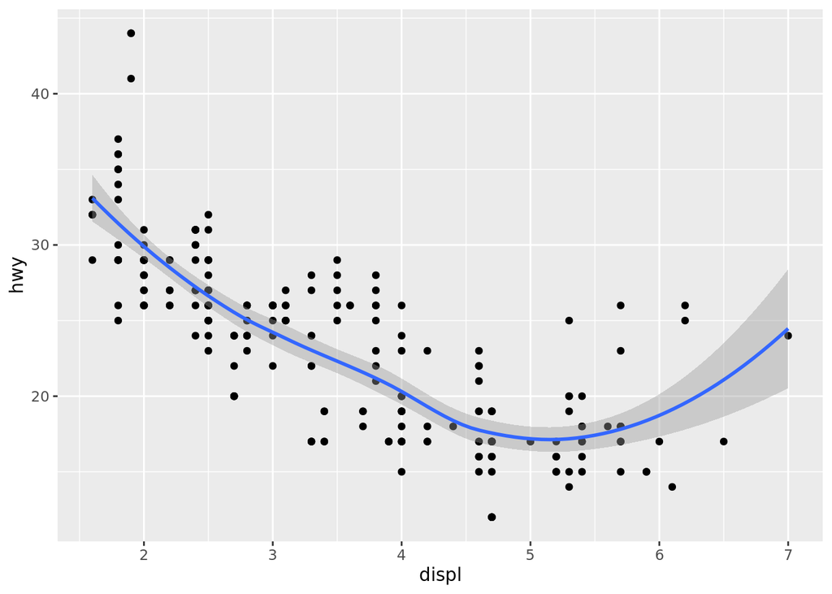

```r
ggplot(data = mpg, mapping = aes(x = displ, y = hwy)) +
  geom_point() +
  geom_smooth()
```

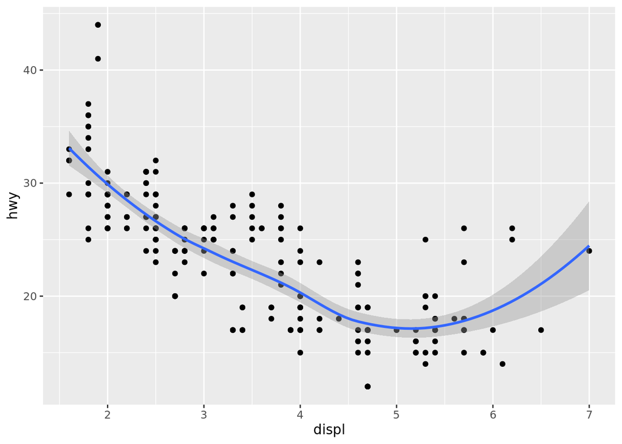

```r
ggplot() +
  geom_point(data = mpg, mapping = aes(x = displ, y = hwy)) +
  geom_smooth(data = mpg, mapping = aes(x = displ, y = hwy))
```

**6. Recreate the R code necessary to generate the following graphs.**

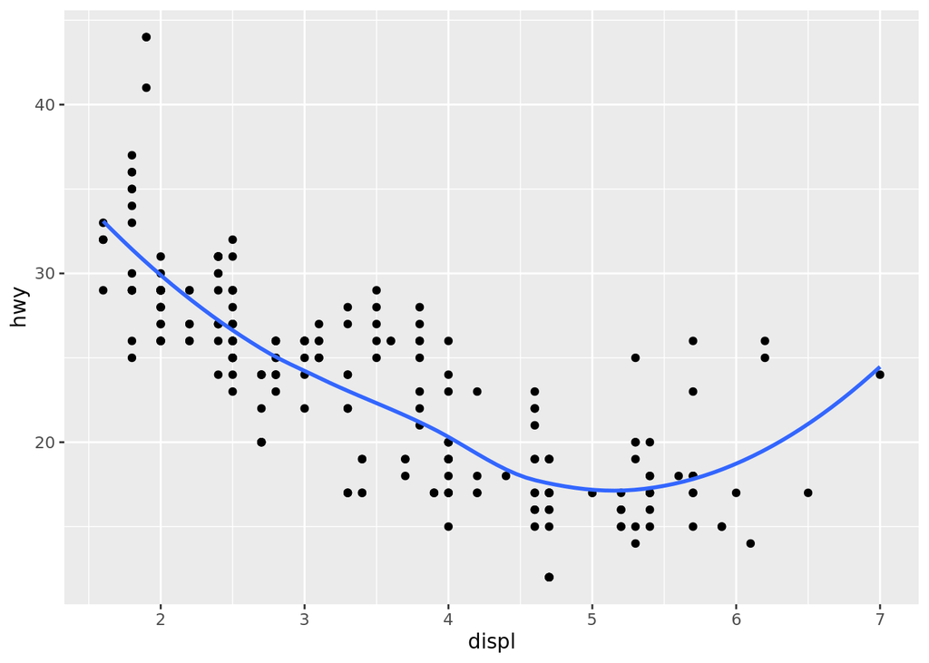

```r
ggplot(data = mpg, mapping = aes(x = displ, y = hwy)) +
  geom_point() +
  geom_smooth(se = FALSE)
```

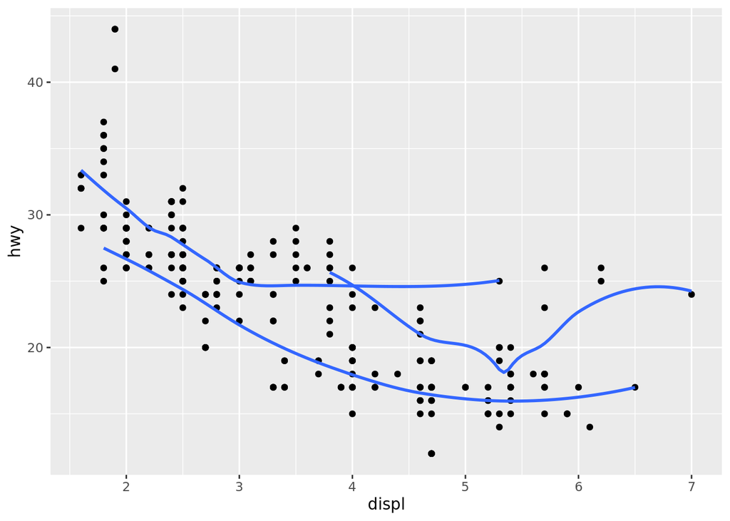

```r
ggplot(data = mpg, mapping = aes(x = displ, y = hwy)) +
  geom_point() +
  geom_smooth(aes(group = drv), se = FALSE)
```

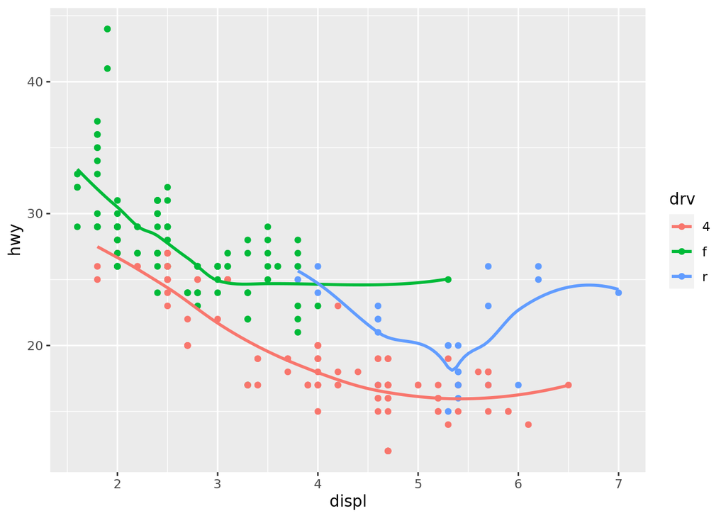

```r
ggplot(data = mpg, mapping = aes(x = displ, y = hwy, color = drv)) +
  geom_point() +
  geom_smooth(aes(group = drv), se = FALSE)
```

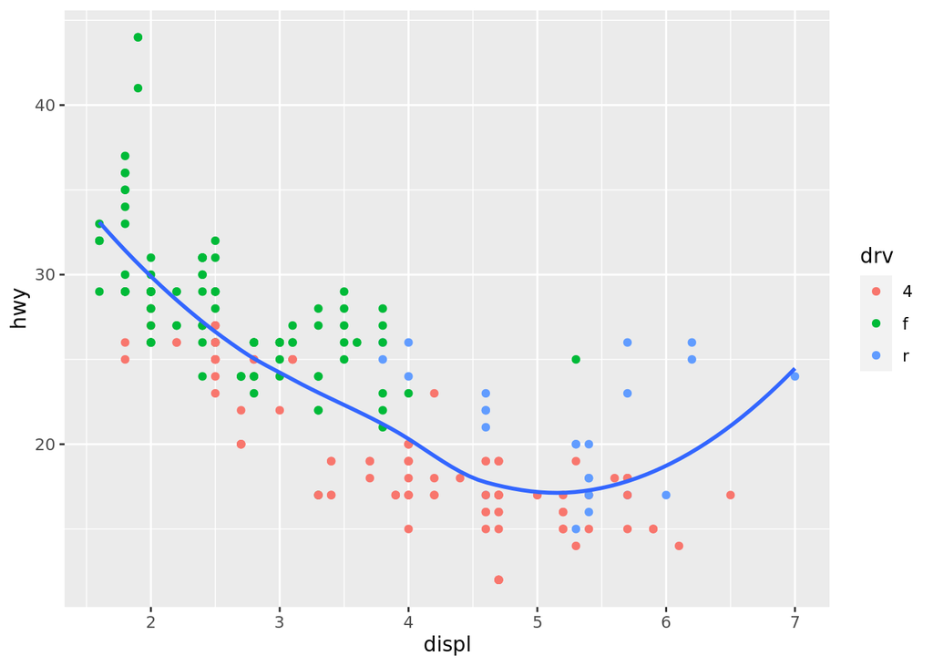

```r
ggplot(data = mpg, mapping = aes(x = displ, y = hwy)) +
  geom_point(aes(color = drv)) +
  geom_smooth(se = FALSE)
```

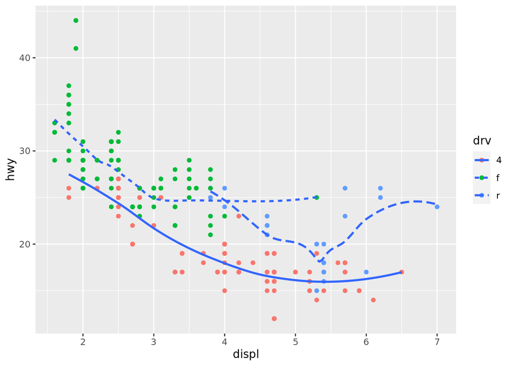

```r
ggplot(data = mpg, mapping = aes(x = displ, y = hwy)) +
  geom_point(aes(color = drv)) +
  geom_smooth(aes(linetype = drv), se = FALSE)
```

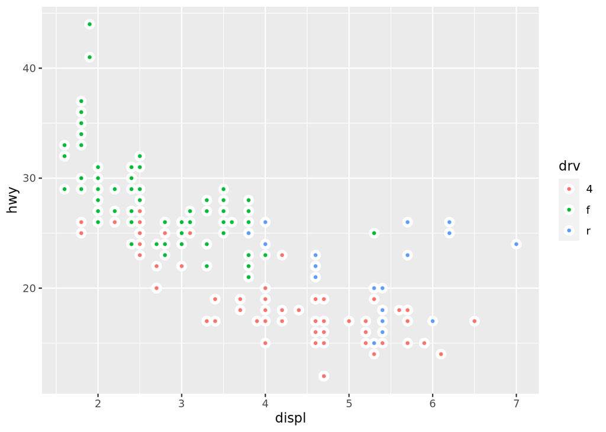

```r
ggplot(data = mpg, mapping = aes(x = displ, y = hwy)) +
  geom_point(aes(fill = drv), shape = 21, color = 'white', stroke = 2)
```

##3.7.1 Exercises

**1. What is the default geom associated with `stat_summary()`? How could you rewrite the previous plot to use that geom function instead of the stat function?**

`geom_pointrange()`

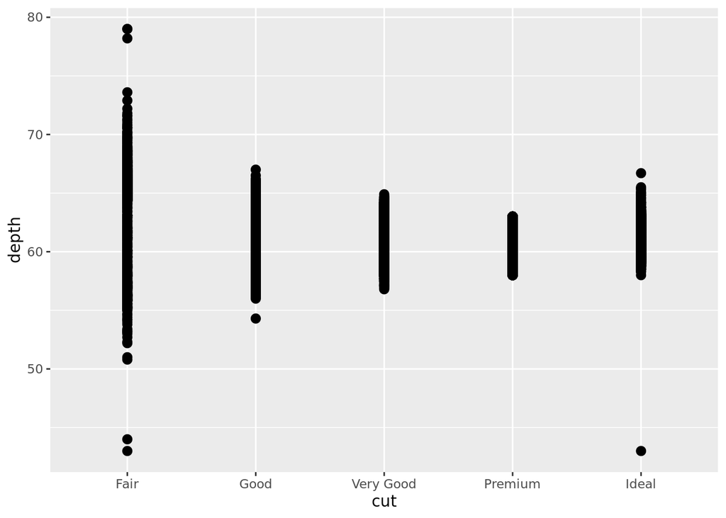

```r
ggplot(data = diamonds) +
  geom_pointrange(mapping = aes(x = cut, y = depth, ymin=depth, ymax=depth))
```

**2. What does `geom_col()` do? How it is different from `geom_bar()`.**

`geom_bar()` makes the height of the bar proportional to the number of cases in each group (or if the weight aesthetic is supplied, the sum of the weights). If you want the heights of the bars to represent values in the data, use `geom_col()` instead. `geom_bar()` uses `stat_count()` by default: it counts the number of cases at each x position. `geom_col()` uses `stat_identity()`: it leaves the data as is.

**3. Most geoms and stats come in pairs that are almost always used in concert. Read through the documentation and make a list of all the pairs. What do they have in common?

**4. What variables does `stat_smooth()` compute? What parameters control its behavior?**

`stat_smooth()` computes the y, the predicted value of y for each x value. Also, it computes the standard error of that value predicted, together with the upper and lower bound of that point prediction. It can compute different methods such as `lm`, `glm`, `lowess` among others. See method in `?stat_smooth`. The statistic can be controlled with the method argument.

**5. In our proportion bar chart, we need to set group = 1. Why? In other words what is the problem with these two graphs?**

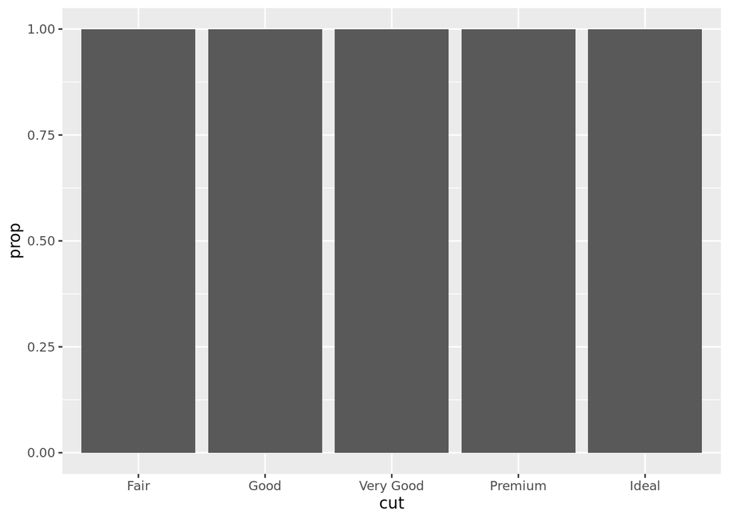

```r
ggplot(data = diamonds) +
  geom_bar(mapping = aes(x = cut, y = ..prop..))
```

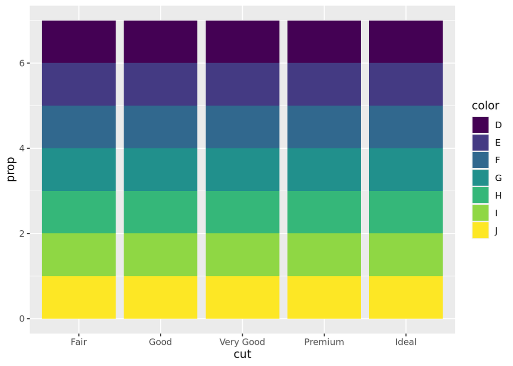

```r
ggplot(data = diamonds) +
  geom_bar(mapping = aes(x = cut, fill = color, y = ..prop..))
```

`group=1` provides a grouping variable for all `cut` values, otherwise all unique values of `prop` are plotted and we something of a stacked bar chart rather than a summary of values on the y-axis.

### 3.8.1 Exercises

**1. What is the problem with this plot? How could you improve it?**

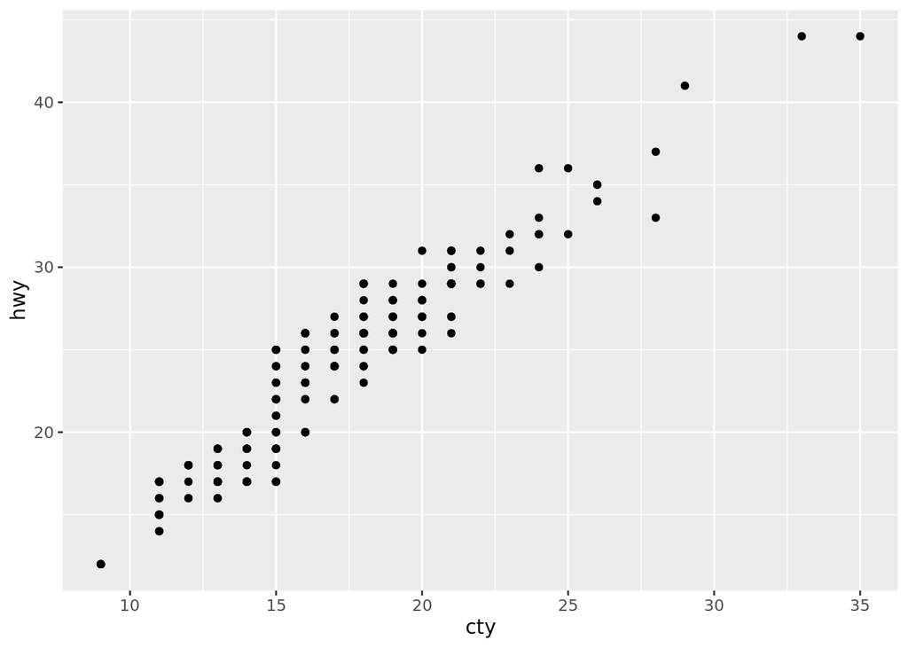

```r
ggplot(data = mpg, mapping = aes(x = cty, y = hwy)) +
  geom_point()
```

There is a lot of over-plotting due the `cty` and `hwy` being somewhat discrete. Changing `geom_point()` to `geom_jitter()` illustrates more of the data.

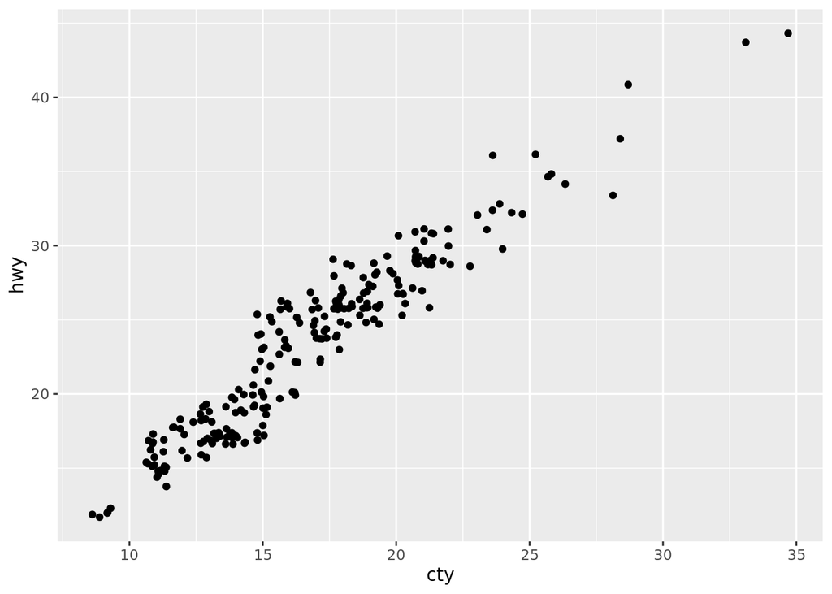

```r
ggplot(data = mpg, mapping = aes(x = cty, y = hwy)) +
  geom_jitter()
```

**2. What parameters to `geom_jitter()` control the amount of jittering?**

`width` and `height` are parameters that control the amount of jitter. Both have the same description and appear to control both horizontal and vertical jitter. Some exploration suggests that `width` controls horizontal jitter and `height` control verical jitter when both are used together.

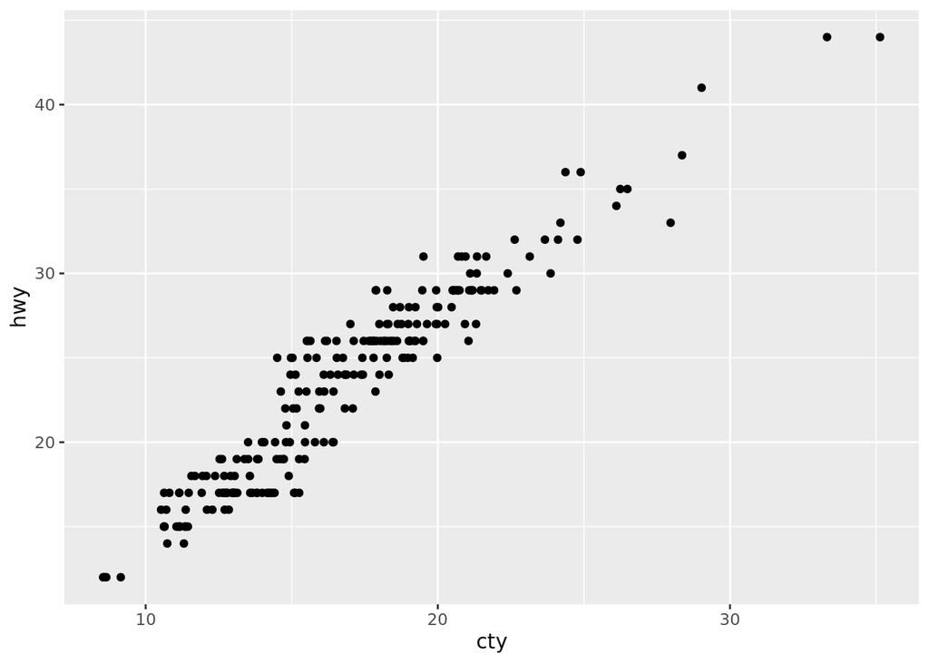

```r
ggplot(data = mpg, mapping = aes(x = cty, y = hwy)) +
  geom_jitter(height=0, width=0.50)
```